# Health Insurance Cross Sell - Part 02

Kleber Moreira

07/02/2024

# 1 Imports

```r
library(tidyverse)
library(janitor)
library(readr)
library(gtsummary)
library(summarytools)
library(kableExtra)
library(knitr)
library(gridExtra)
library(summarytools)
library(randomForest)
library(reshape2)
library(tidymodels)
```

# 2 Helper Functions

## 2.1 Top @K precision and recall

This function returns a dataframe with K rows. The last row will have the values of @K metrics.

```r
# Creating function  --------------------------
metrics_at_k_function <- function(model_name, model_results, k){

  df_results <- model_results %>%
    arrange(desc(.pred_yes)) %>%
    mutate(
      TP = ifelse(.pred_class == "yes" & response == "yes", 1, 0),
      FP = ifelse(.pred_class == "yes" & response == "no", 1, 0),
      FN = ifelse(.pred_class == "no" & response == "yes", 1, 0),
      TN = ifelse(.pred_class == "no" & response == "no", 1, 0)
      )

  # Create list for precision and recall
  precision_at_k <- list()
  recall_at_k <- list()

  # Populate the metric list
  for (i in 1:k) {
    subset_k <- df_results %>%
    dplyr_row_slice(1:i)

    precision_at_k[[i]] <- (subset_k$TP %>% sum())/(subset_k$TP %>% sum() + subset_k$FP %>% sum())

    recall_at_k[[i]] <- (subset_k$TP %>% sum())/(subset_k$TP %>% sum() + subset_k$FN %>% sum())
}

  # Complete dataframe
    metrics_at_k_df <- df_results %>%
      dplyr_row_slice(1:k) %>%
      mutate(
        precision_at_k = unlist(precision_at_k),
        recall_at_k = unlist(recall_at_k)
        )

    final_at_k_df <- tibble(model = model_name, k = k) %>%
      bind_cols(
        metrics_at_k_df %>%
          slice(k) %>%
          select(precision_at_k, recall_at_k)
      )



    return(list(metrics_at_k_df, final_at_k_df))
}
```

## 2.2 Gain & Lift Curves

```r
curves_function <-  function(model_results){
  gain_plt <- gain_curve(model_results, response, .pred_yes) %>%
  autoplot()

  lift_plt <- lift_curve(model_results, response, .pred_yes) %>%    autoplot()

  return(gridExtra::grid.arrange(gain_plt, lift_plt, ncol = 2))
}
```

# 3 Data Collection

```r
df_selected <- readRDS("df_selected.rds")
```

# 4 Pre-processing

```r
region_encoder <- readRDS("region_encoder.rds")
policy_encoder <- readRDS("policy_encoder.rds")

# Create function
encoder_function <- function(df){
  df %>%
  left_join(region_encoder) %>%
  select(-region_code) %>%
  rename(region_code = region_num) %>%
  left_join(policy_encoder) %>%
  select(-policy_sales_channel) %>%
  rename(policy_sales_channel = policy_num)
}
```

```r
df_selected <- encoder_function(df_selected)
```

## 4.1 Split into train and test datasets

```r
set.seed(123)

df_split <- df_selected %>%
  initial_split(prop = 0.80, strata = response)

df_train <- df_split %>%
  training()

df_test <- df_split %>%
  testing()
```

## 4.2 Applying steps

```r
# Write the recipe ------------------------
df_recipe <- recipe(response ~ .,
       data = df_train %>% select(-id)) %>%
  step_normalize(age, days_associated) %>%
  step_scale(health_annual_paid) %>%
  step_dummy(all_nominal(), -all_outcomes())

# Train the recipe -----------------------
df_prep <- df_recipe %>%
  prep(training = df_train)

df_train_preprocessed <- df_prep %>%
  bake(new_data = df_train)

df_test_preprocessed <- df_prep %>%
  bake(new_data = df_test)
```

# 5 Logistic Regression 💻

**Training time**: 2.27 seconds.

```r
# Model Specification -----------
logistic_model <- logistic_reg() %>%
  set_engine('glm') %>%
  set_mode('classification')

# Model Fitting -----------
start_time <- Sys.time()

logistic_fit <- logistic_model %>%
  fit(response ~.,
      data = df_train_preprocessed)

end_time <- Sys.time()

print(end_time - start_time)

# Save result in RDS -----------
saveRDS(logistic_fit, "logistic_fit.rds")
```

```r
# Read RDS result -----------
logistic_fit <- readRDS("logistic_fit.rds")

# Prediction ----------
## Classes ------------
class_preds <- logistic_fit %>%
  predict(new_data = df_test_preprocessed,
          type = 'class')
## Probabilities ------------
prob_preds <- logistic_fit %>%
  predict(new_data = df_test_preprocessed,
          type = 'prob')

# Combine results -----------
lr_results <- df_test %>%
  select(id, response) %>%
  bind_cols(class_preds, prob_preds)

# Confusion Matrix ------------
confusion_matrix_lr <-  conf_mat(
  lr_results, truth = response, estimate = .pred_class
)

# Final @K Metrics --------------------
lr_metrics_at_K <- metrics_at_k_function(
  "Logistic Regression",
  lr_results, 2000)
lr_metrics_at_K[[2]]
```

| model | k | precision_at_k | recall_at_k |
| --- | --- | --- | --- |
| Logistic Regression | 2000 | NaN | 0 |

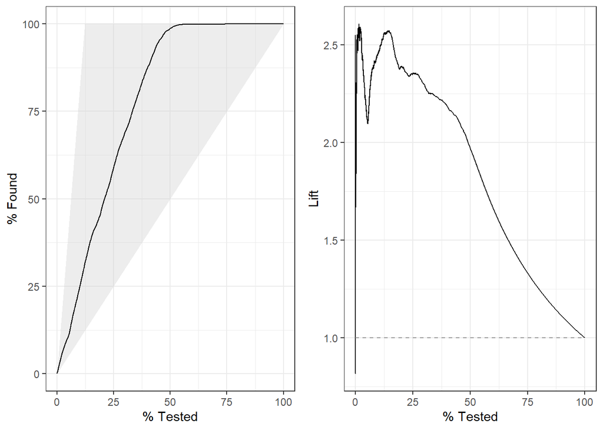

```r
# Save metrics in RDS
saveRDS(lr_metrics_at_K, "lr_metrics_at_K.rds")

# Gain and lift curves ---------------
curves_function(lr_results)
```

**Gain**: By approaching 25% of the ordered list, ~60% of all interested customers are reached.

**Lift**: By approaching 25% of the ordered list, the model performs ~2.3 times better than the random list.

# 6 Decision Tree 💻

**Training time**: 0.97 seconds.

```r
# Model Specification -----------
dt_model <- decision_tree(tree_depth = 20) %>%
  set_engine("rpart") %>%
  set_mode("classification")

# Model Fitting -----------
start_time <- Sys.time()

dt_fit <- dt_model %>%
  fit(response ~ .,
      data = df_train_preprocessed)

end_time <- Sys.time()

print(end_time - start_time)

# Save result in RDS -----------
saveRDS(dt_fit, "dt_fit.rds")
```

```r
# Read RDS result -----------
dt_fit <- readRDS("dt_fit.rds")

# Prediction ----------
## Classes ------------
class_preds <- dt_fit %>%
  predict(new_data = df_test_preprocessed,
          type = 'class')
## Probabilities ------------
prob_preds <- dt_fit %>%
  predict(new_data = df_test_preprocessed,
          type = 'prob')

# Combine results -----------
dt_results <- df_test %>%
  select(id, response) %>%
  bind_cols(class_preds, prob_preds)

# Confusion Matrix ------------
confusion_matrix_dt <-  conf_mat(
  dt_results, truth = response, estimate = .pred_class
)

# Final @K Metrics --------------------
dt_metrics_at_K <- metrics_at_k_function(
  "Decision Tree",
  dt_results, 2000)
dt_metrics_at_K[[2]]
```

| model | k | precision_at_k | recall_at_k |
| --- | --- | --- | --- |
| Decision Tree | 2000 | NaN | 0 |

```r
# Save results in rds
saveRDS(dt_metrics_at_K, "dt_metrics_at_K.rds")

# Gain and lift curves ---------------
# curves_function(dt_results)
```

For this model, in particular, it is not possible to plot the gain and lift curves, because there is no variation in the probabilities for “yes” and “no”, as you can see below:

```r
dt_metrics_at_K[[1]] %>%
  select(.pred_yes, .pred_no) %>%
  summary()
```

```
##    .pred_yes         .pred_no
##  Min.   :0.1226   Min.   :0.8774
##  1st Qu.:0.1226   1st Qu.:0.8774
##  Median :0.1226   Median :0.8774
##  Mean   :0.1226   Mean   :0.8774
##  3rd Qu.:0.1226   3rd Qu.:0.8774
##  Max.   :0.1226   Max.   :0.8774
```

# 7 Random Forest 💻

**Training time**: 7.56 minutes.

```r
# Model Specification -----------
rf_model <- rand_forest(
  mtry = 3,
  trees = 1000,
  min_n = 100
) %>%
  set_mode("classification") %>%
  set_engine("ranger")

# Model Fitting -----------
start_time <- Sys.time()

rf_fit <- rf_model %>%
  fit(response ~ .,
      data = df_train_preprocessed)

end_time <- Sys.time()

print(end_time - start_time)

# Save result in RDS -----------
saveRDS(rf_fit, "rf_fit.rds")
```

```r
# Read RDS result -----------
rf_fit <- readRDS("rf_fit.rds")

# Prediction ----------
## Classes ------------
class_preds <- rf_fit %>%
  predict(new_data = df_test_preprocessed,
          type = 'class')
## Probabilities ------------
prob_preds <- rf_fit %>%
  predict(new_data = df_test_preprocessed,
          type = 'prob')

# Combine results -----------
rf_results <- df_test %>%
  select(id, response) %>%
  bind_cols(class_preds, prob_preds)

# Confusion Matrix ------------
confusion_matrix_rf <-  conf_mat(
  rf_results, truth = response, estimate = .pred_class
)

# Final @K Metrics --------------------
rf_metrics_at_K <- metrics_at_k_function(
  "Random Forest",
  rf_results, 2000)
rf_metrics_at_K[[2]]
```

| model | k | precision_at_k | recall_at_k |
| --- | --- | --- | --- |
| Random Forest | 2000 | 0.4216867 | 0.08130081 |

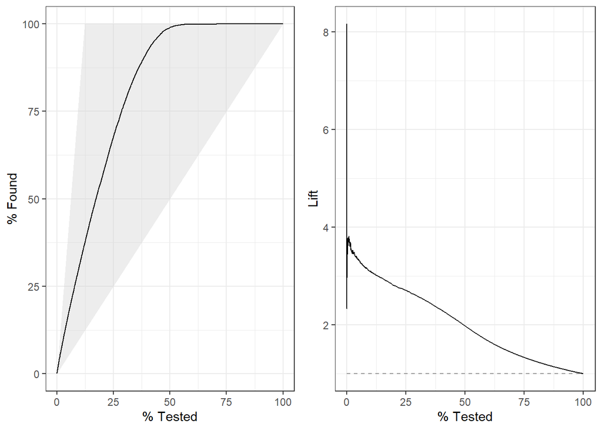

```r
# Save results in rds
saveRDS(rf_metrics_at_K, "rf_metrics_at_K.rds")

# Gain and lift curves ---------------
curves_function(rf_results)
```

**Gain**: By approaching 25% of the ordered list, ~65% of all interested customers are reached.

**Lift**: By approaching 25% of the ordered list, the model performs ~2.7 times better than the random list.

# 8 XGBoost 💻

**Training time**: 5.21 minutes.

```r
# Model Specification -----------
xgb_model <- boost_tree(
  mtry = 6,
  trees = 1000,
  min_n = 28,
  tree_depth = 14,
  loss_reduction = 0.01,
  sample_size = 0.27
  ) %>%
  set_mode("classification") %>%
  set_engine("xgboost")

# Model Fitting -----------
start_time <- Sys.time()

xgb_fit <- xgb_model %>%
  fit(response ~ .,
      data = df_train_preprocessed)

end_time <- Sys.time()

print(end_time - start_time)

# Save result in RDS -----------
saveRDS(xgb_fit, "xgb_fit.rds")
```

```r
# Read RDS result -----------
xgb_fit <- readRDS("xgb_fit.rds")

# Prediction ----------
## Classes ------------
class_preds <- xgb_fit %>%
  predict(new_data = df_test_preprocessed,
          type = 'class')
## Probabilities ------------
prob_preds <- xgb_fit %>%
  predict(new_data = df_test_preprocessed,
          type = 'prob')

# Combine results -----------
xgb_results <- df_test %>%
  select(id, response) %>%
  bind_cols(class_preds, prob_preds)

# Confusion Matrix ------------
confusion_matrix_xgb <-  conf_mat(
  xgb_results, truth = response, estimate = .pred_class
)

# Final @K Metrics --------------------
xgb_metrics_at_K <- metrics_at_k_function(
  "XGBoost",
  xgb_results, 2000)
xgb_metrics_at_K[[2]]
```

| model | k | precision_at_k | recall_at_k |
| --- | --- | --- | --- |
| XGBoost | 2000 | 0.345 | 1 |

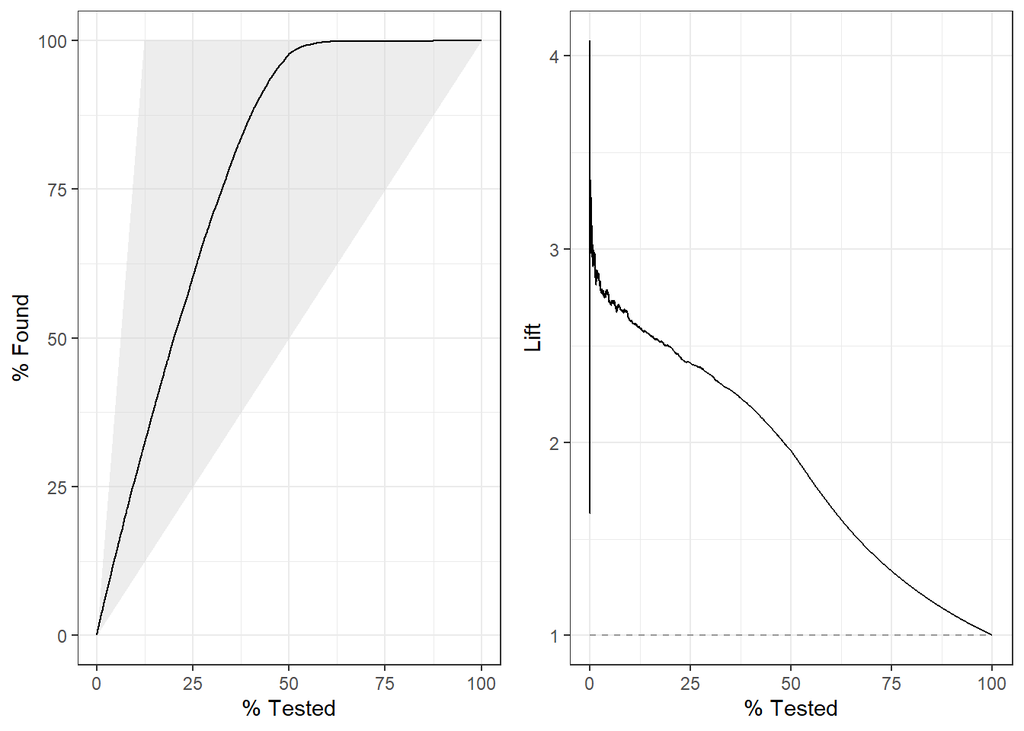

```r
# Save results in rds
saveRDS(xgb_metrics_at_K, "xgb_metrics_at_K.rds")

# Gain and lift curves ---------------
curves_function(xgb_results)
```

**Gain**: By approaching 25% of the ordered list, ~61% of all interested customers are reached.

**Lift**: By approaching 25% of the ordered list, the model performs ~2.4 times better than the random list.

# 9 KNN 💻

**Training time**: 18.67 mins.

**Prediction time: 9.54 mins.**

```r
library(kknn)
# Model Specification -----------
knn_model <- nearest_neighbor(weight_func = "rectangular",
                              neighbors = 3) %>%
  set_mode("classification") %>%
  set_engine("kknn")

# Paralleliza fitting process
doParallel::registerDoParallel()

# Model Fitting -----------
start_time <- Sys.time()

knn_fit <- knn_model %>%
  fit(response ~ .,
      data = df_train_preprocessed)

end_time <- Sys.time()

print(end_time - start_time)

# Save result in RDS -----------
saveRDS(knn_fit, "knn_fit.rds")

# Read RDS result -----------
knn_fit <- readRDS("knn_fit.rds")

# Paralleliza prediction process
doParallel::registerDoParallel()

# Prediction ----------
start_time <- Sys.time()
## Classes ------------
class_preds <- knn_fit %>%
  predict(new_data = df_test_preprocessed,
          type = 'class')
## Probabilities ------------
prob_preds <- knn_fit %>%
  predict(new_data = df_test_preprocessed,
          type = 'prob')

end_time <- Sys.time()
print(end_time - start_time)
```

```r
# Combine results -----------
knn_results <- df_test %>%
  select(id, response) %>%
  bind_cols(class_preds, prob_preds)

# Confusion Matrix ------------
confusion_matrix_knn <-  conf_mat(
  knn_results, truth = response, estimate = .pred_class
)

# Final @K Metrics --------------------
knn_metrics_at_K <- metrics_at_k_function(
  "KNN",
  knn_results, 2000)
knn_metrics_at_K[[2]]
```

| model | k | precision_at_k | recall_at_k |
| --- | --- | --- | --- |
| KNN | 2000 | 0.345 | 1 |

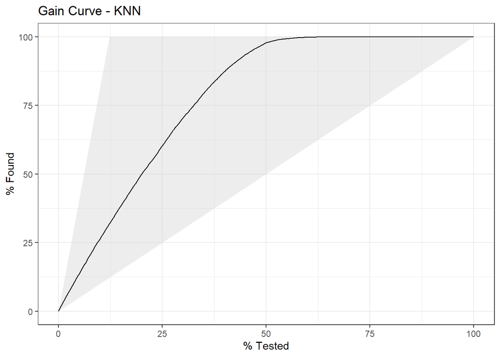

```r
# Save results in rds
saveRDS(knn_metrics_at_K, "knn_metrics_at_K.rds")

# Gain and lift curves ---------------
plt_gain_knn <- gain_curve(knn_results, response, .pred_yes) %>%
  autoplot()

plt_gain_knn +
  ggtitle("Gain Curve - KNN")
```

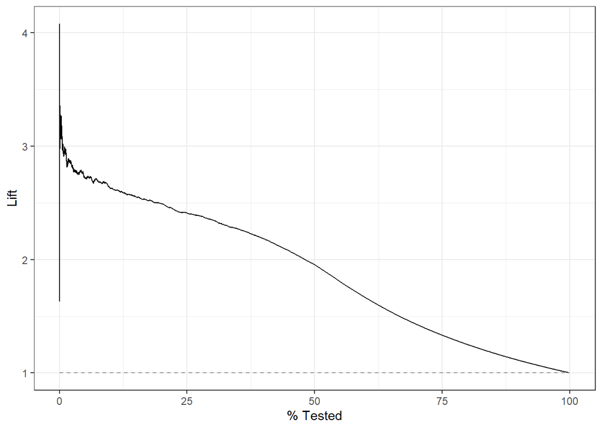

```r
lift_curve(knn_results, response, .pred_yes) %>%
  autoplot()
```

# 10 **Models Single Performance**

```r
# Reading model results
lr_metrics <- readRDS("lr_metrics_at_K.rds")
rf_metrics <- readRDS("rf_metrics_at_K.rds")
dt_metrics <- readRDS("dt_metrics_at_K.rds")
xgb_metrics <- readRDS("xgb_metrics_at_K.rds")
knn_metrics <- readRDS("knn_metrics_at_K.rds")

# Showing a table comparing models
models_comparison_df <- lr_metrics[[2]] %>%
  bind_rows(rf_metrics[[2]],
            dt_metrics[[2]],
            xgb_metrics[[2]],
            knn_metrics[[2]])

models_comparison_df
```

| model | k | precision_at_k | recall_at_k |
| --- | --- | --- | --- |
| Logistic Regression | 2000 | NaN | 0.00000000 |
| Random Forest | 2000 | 0.4216867 | 0.08130081 |
| Decision Tree | 2000 | NaN | 0.00000000 |
| XGBoost | 2000 | 0.3450000 | 1.00000000 |
| KNN | 2000 | 0.3450000 | 1.00000000 |

Among the trained models, if we have to choose at this point, we would pick the model with the higher recall @K. In this way, either KNN or XGBoost would give us the best result. However, the XGBoost model takes less time to run, thus this model would be selected.